# PSET 1

Vivian Xiao

1/27/2017

```r
#load packages needed for this assignment
library(tidyverse)
```

# Part 1: Data cleaning

First, we look at the raw data.

```r
d = read.csv("~/Desktop/PSYC254/data/problem_sets/data/janiszewski_rep_exercise.csv")
str(d)
```

```
## 'data.frame':    90 obs. of  34 variables:
##  $ HITId                      : Factor w/ 3 levels "261WKUDD8XMBJ8COBQ261TO6T1XNCJ",..: 1 1 1 1 1 1 1 1 1 1 ...
##  $ HITTypeId                  : Factor w/ 1 level "2DVGTP9RA7S5C4ALLOJOM70JMHCRW9": 1 1 1 1 1 1 1 1 1 1 ...
##  $ Title                      : Factor w/ 1 level "How much is it worth? Quick 2 minute survey.": 1 1 1 1 1 1 1 1 1 1 ...
##  $ Description                : Factor w/ 1 level "A quick two minute survey asking about prices. DO THIS HIT ONLY ONCE.": 1 1 1 1 1 1 1 1 1 1 ...
##  $ Keywords                   : Factor w/ 1 level "survey, quick, prices": 1 1 1 1 1 1 1 1 1 1 ...
##  $ Reward                     : num  0.1 0.1 0.1 0.1 0.1 0.1 0.1 0.1 0.1 0.1 ...
##  $ CreationTime               : Factor w/ 1 level "Wed Jan 25 18:13:24 GMT 2012": 1 1 1 1 1 1 1 1 1 1 ...
##  $ MaxAssignments             : int  30 30 30 30 30 30 30 30 30 30 ...
##  $ RequesterAnnotation        : Factor w/ 1 level "Department:Other": 1 1 1 1 1 1 1 1 1 1 ...
##  $ AssignmentDurationInSeconds: int  600 600 600 600 600 600 600 600 600 600 ...
##  $ AutoApprovalDelayInSeconds : int  604800 604800 604800 604800 604800 604800 604800 604800 604800 604800 ...
##  $ Expiration                 : Factor w/ 1 level "Wed Feb 01 18:13:24 GMT 2012": 1 1 1 1 1 1 1 1 1 1 ...
##  $ NumberOfSimilarHITs        : int  2 2 2 2 2 2 2 2 2 2 ...
##  $ LifetimeInSeconds          : logi  NA NA NA NA NA NA ...
```

[output cut: 20 more lines]

In this format, the data is probably going to be difficult or unwieldy to work with. This is because a) it has a lot of extraneous info that we need to clean out first (i.e. information Qualtrics automatically gives you that isn’t necessarily pertinent) and b) it’s in wide format (i.e. multiple observations per participant per row) and we need long format and c) any potential empty cells, or duplications haven’t been cleaned out.

# Part 2: Making data tidy

Next, we take a look at the cleaned dataset.

```r
d = read.csv("~/Desktop/PSYC254/data/problem_sets/data/janiszewski_rep_cleaned.csv")
str(d)
```

```
## 'data.frame':    87 obs. of  34 variables:
##  $ HITId                      : Factor w/ 3 levels "261WKUDD8XMBJ8COBQ261TO6T1XNCJ",..: 1 1 1 1 1 1 1 1 1 1 ...
##  $ HITTypeId                  : Factor w/ 1 level "2DVGTP9RA7S5C4ALLOJOM70JMHCRW9": 1 1 1 1 1 1 1 1 1 1 ...
##  $ Title                      : Factor w/ 1 level "How much is it worth? Quick 2 minute survey.": 1 1 1 1 1 1 1 1 1 1 ...
##  $ Description                : Factor w/ 1 level "A quick two minute survey asking about prices. DO THIS HIT ONLY ONCE.": 1 1 1 1 1 1 1 1 1 1 ...
##  $ Keywords                   : Factor w/ 1 level "survey, quick, prices": 1 1 1 1 1 1 1 1 1 1 ...
##  $ Reward                     : num  0.1 0.1 0.1 0.1 0.1 0.1 0.1 0.1 0.1 0.1 ...
##  $ CreationTime               : Factor w/ 1 level "Wed Jan 25 18:13:24 GMT 2012": 1 1 1 1 1 1 1 1 1 1 ...
##  $ MaxAssignments             : int  30 30 30 30 30 30 30 30 30 30 ...
##  $ RequesterAnnotation        : Factor w/ 1 level "Department:Other": 1 1 1 1 1 1 1 1 1 1 ...
##  $ AssignmentDurationInSeconds: int  600 600 600 600 600 600 600 600 600 600 ...
##  $ AutoApprovalDelayInSeconds : int  604800 604800 604800 604800 604800 604800 604800 604800 604800 604800 ...
##  $ Expiration                 : Factor w/ 1 level "Wed Feb 01 18:13:24 GMT 2012": 1 1 1 1 1 1 1 1 1 1 ...
##  $ NumberOfSimilarHITs        : int  2 2 2 2 2 2 2 2 2 2 ...
##  $ LifetimeInSeconds          : logi  NA NA NA NA NA NA ...
```

[output cut: 20 more lines]

```r
d.tidy = select(d, WorkerId, Input.condition:Input.price3, Answer.dog_cost:Answer.sushi_cost)
d.tidy = d.tidy %>%
  rename(condition=Input.condition) %>%
  rename(dog_anchor=Input.price1) %>%
  rename(plasma_anchor=Input.price2) %>%
  rename(sushi_anchor=Input.price3)%>%
  rename(dog_cost=Answer.dog_cost) %>%
  rename(plasma_cost=Answer.plasma_cost) %>%
  rename(sushi_cost=Answer.sushi_cost)%>%
  mutate(WorkerId=1:n())

d.tidy = d.tidy %>%
  gather(name, cost,
         dog_anchor, plasma_anchor, sushi_anchor,
         dog_cost, plasma_cost, sushi_cost) %>%
  separate(name, c("item", "type"), "_") %>%
  spread(type, cost)
```

We select only the variables of interest (subject ID, anchoring condition, anchoring price, and participant’s bet), and then we rename the variables into something more easily understood. Finally, we convert the data from wide format to long format for ease of analysis. This is the form that is most convenient to run analyses in.

# Part 3: Manipulating data using dplyr

Using the cleaned dataset from **Part 2** above, we plot the data to see, visually, whether or not it looks like the effect replicated.

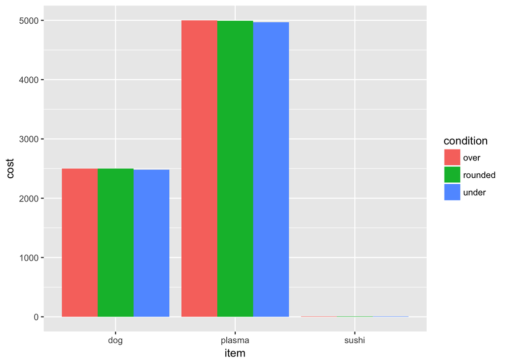

```r
ggplot(d.tidy, aes(x=item, y=cost, group=condition,fill=condition)) +
     geom_bar(stat="identity", position="dodge")
```

This graph is pretty difficult to interpret because the three items are on different scales. If we clean the data some more to get standardized outcome variables, we may be able to more easily compare the three types of items and the responses that participants gave for them.

Here, we go through the process of manipulating the data to more easily compare the mean price given for each item in each condition.

```r
d.raw = read.csv("~/Desktop/PSYC254/data/problem_sets/data/janiszewski_rep_exercise.csv",stringsAsFactors = F)
d.unique.subs = (d.raw %>%
                   group_by(WorkerId) %>%
                   filter(row_number() == 1))

m_grand = d.unique.subs %>%
  group_by(Input.condition) %>%
  summarise(m_dog = mean(as.numeric(Answer.dog_cost), na.rm = TRUE), m_plasma = mean(as.numeric(Answer.plasma_cost), na.rm = TRUE), m_sushi = mean(as.numeric(Answer.sushi_cost), na.rm = TRUE))
print(m_grand)
```

```
## # A tibble: 3 × 4
##   Input.condition    m_dog m_plasma  m_sushi
##             <chr>    <dbl>    <dbl>    <dbl>
## 1            over 1894.793 4300.333 8.342857
## 2         rounded 1884.482 4094.929 7.953929
## 3           under 1959.074 3857.659 7.742500
```

```r
m_grand2 = d.tidy %>%
  group_by(condition) %>%
  summarize(mean(cost, na.rm=TRUE))
print(m_grand2)
```

```
## # A tibble: 3 × 2
##   condition `mean(cost, na.rm = TRUE)`
##      <fctr>                      <dbl>
## 1      over                   2092.139
## 2   rounded                   1994.698
## 3     under                   1977.688
```

In order to better examine this effect, we then clean the data further and standardize the responses against the anchor values in two ways.

```r
d.tidy <- d %>%
  select(WorkerId, Input.condition,
         starts_with("Answer"),
         starts_with("Input")) %>%
  rename(workerid = WorkerId,
         condition = Input.condition,
         plasma_anchor = Input.price1,
         dog_anchor = Input.price2,
         sushi_anchor = Input.price3,
         dog_cost = Answer.dog_cost,
         plasma_cost = Answer.plasma_cost,
         sushi_cost = Answer.sushi_cost) %>%
  gather(name, cost,
         dog_anchor, plasma_anchor, sushi_anchor,
         dog_cost, plasma_cost, sushi_cost) %>%
  separate(name, c("item", "type"), "_") %>%
  spread(type, cost)
```

First, we standardize using percent change.

```r
ps = d.tidy %>%
  mutate(p_change = ((anchor-cost)/anchor)*100) #percent change (decrease)

p_table = ps %>%
  group_by(condition) %>%
  summarise(m_dog = mean(p_change[item == "dog"], na.rm=T), m_plasma = mean(p_change[item=="plasma"],na.rm=T), m_sushi=mean(p_change[item=="sushi"],na.rm=T))
print(p_table)
```

[output not shown]

```r
p_table.a = ps %>%
  group_by(condition) %>%
  summarize(mean(p_change, na.rm=T))
print(p_table.a)
```

```
## # A tibble: 3 × 2
##   condition `mean(p_change, na.rm = T)`
##      <fctr>                       <dbl>
## 1      over                    16.59279
## 2   rounded                    18.13099
## 3     under                    17.76793
```

Next, we examine what results look like when we examine cost as a z-score.

```r
ps1 = d.tidy %>%
  mutate(z=scale(cost)[,1]) #z score

p_table2 = ps1 %>%
  group_by(condition) %>%
  summarise(m_dog = mean(z[item == "dog"],na.rm=T), m_plasma = mean(z[item=="plasma"],na.rm=T), m_sushi=mean(z[item=="sushi"],na.rm=T))
print(p_table2)
```

```
## # A tibble: 3 × 4
##   condition       m_dog m_plasma   m_sushi
##      <fctr>       <dbl>    <dbl>     <dbl>
## 1      over -0.07003565 1.283835 -1.135294
## 2   rounded -0.07782373 1.166217 -1.135501
## 3     under -0.06515216 1.124903 -1.135621
```

```r
p_table2.a = ps1 %>%
  group_by(condition) %>%
  summarize(mean(z, na.rm=T))
print(p_table2.a)
```

```
## # A tibble: 3 × 2
##   condition `mean(z, na.rm = T)`
##      <fctr>                <dbl>
## 1      over           0.03921865
## 2   rounded          -0.01570251
## 3     under          -0.02528979
```

As z-scores, we see again that the effect does not appear to hold. For both sushi and dogs, there doesn’t appear to be a big, appreciable change in cost based on condition, and again, for dogs, the over and rounded conditions don’t seem to be appreciably different. Again, the plasma condition does show the expected effect - the z scores get smaller when comparing over to rounded to under. When looking at the results across items, it does look like the results point to the effect holding, but the differences between the three conditions are so small that we can’t be confident in this.

Finally, we graph the standardized data to again visualize the results, but this time with more intepretable information.

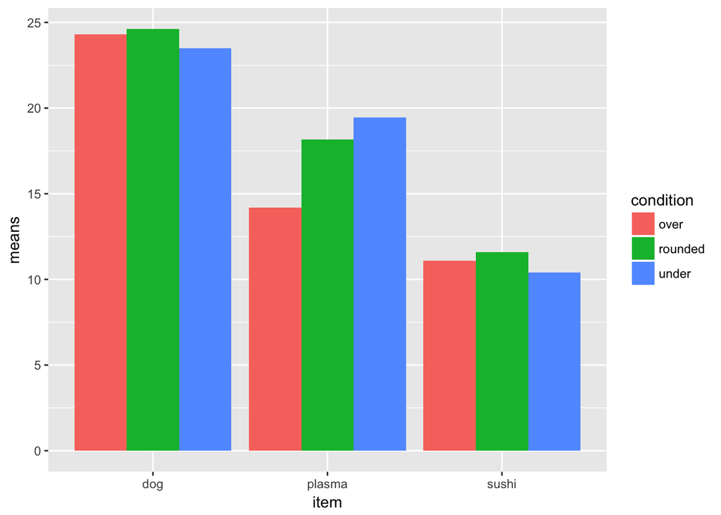

```r
ps.a = ps %>%
  group_by(item, condition) %>%
  summarise(means=mean(p_change, na.rm=T))

ggplot(ps.a, aes(x=item, y=means, group=condition,fill=condition)) +
     geom_bar(stat="identity", position="dodge")
```

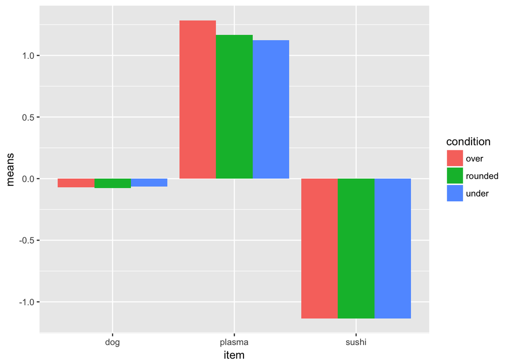

```r
ps1.a = ps1 %>%
  group_by(item, condition) %>%
  summarise(means=mean(z, na.rm=T))

ggplot(ps1.a, aes(x=item, y=means, group=condition,fill=condition)) +
     geom_bar(stat="identity", position="dodge")
```

In both cases, when standardized, the effect does not seem to replicate perfectly. Although plasma shows effects in the expected direction when using both methods of standardization, the effect for dogs and sushi is not what we expected. Whereas it was unclear with the unstandardized scores whether or not the effect replicated because of the different scales the three different items had, when standardized it is clear that the replication is not perfect.